# Winter 2022 Data Science Intern Challenge

## **Question 1**

### **Case Study**

On Shopify, there are exactly 100 sneaker shops, each shop sells only one model of shoe. We do some analysis to find the average order value (AOV) across all ordered shoes for a period of 30 days, we calculate an AOV of $3145.13. But this price seems unreal given that there are sneakers and are relatively affordable, something seems wrong with our analysis.

Given a dataset with relevant order details and the brief explanation above we are to:

1. Think about what could be going wrong with our calculation. Think about a better way to evaluate this data.
2. What metric would you report for this dataset?
3. What is its value?

```python
# Importing dependencies
import pandas as pd
import matplotlib.pyplot as plt
```

**Lets go into this dataset and see what we can make of it...**

```python
dataset = pd.read_csv('Sneakers.csv')
dataset.head()
```

|  | order_id | shop_id | user_id | order_amount | total_items | payment_method | created_at |
| --- | --- | --- | --- | --- | --- | --- | --- |
| 0 | 1 | 53 | 746 | 224 | 2 | cash | 2017-03-13 12:36:56 |
| 1 | 2 | 92 | 925 | 90 | 1 | cash | 2017-03-03 17:38:52 |
| 2 | 3 | 44 | 861 | 144 | 1 | cash | 2017-03-14 4:23:56 |
| 3 | 4 | 18 | 935 | 156 | 1 | credit_card | 2017-03-26 12:43:37 |
| 4 | 5 | 18 | 883 | 156 | 1 | credit_card | 2017-03-01 4:35:11 |

```python
dataset.info()
```

```
<class 'pandas.core.frame.DataFrame'>
RangeIndex: 5000 entries, 0 to 4999
Data columns (total 7 columns):
 #   Column          Non-Null Count  Dtype
---  ------          --------------  -----
 0   order_id        5000 non-null   int64
 1   shop_id         5000 non-null   int64
 2   user_id         5000 non-null   int64
 3   order_amount    5000 non-null   int64
 4   total_items     5000 non-null   int64
 5   payment_method  5000 non-null   object
 6   created_at      5000 non-null   object
dtypes: int64(5), object(2)
memory usage: 273.6+ KB
```

```python
# Create a column in the dataset containing the price of one item
dataset['price_of_one'] = dataset['order_amount'] // dataset['total_items']
```

```python
print("Lowest price of one sneaker sold: ${}".format(dataset['price_of_one'].min()))
print("Highest price of one sneaker sold: ${}".format(dataset['price_of_one'].max()))
print("Average price of sneakers: ${}".format(dataset['order_amount'].mean()))
```

```
Lowest price of one sneaker sold: $90
Highest price of one sneaker sold: $25725
Average price of sneakers: $3145.128
```

```python
print("First order date and time: ", dataset['created_at'].min())
print("Last order date and time: ", dataset['created_at'].max())
```

```
First order date and time:  2017-03-01 0:08:09
Last order date and time:  2017-03-30 9:55:00
```

From the observations above we can tell there are 5000 orders, No missing values, orders span 30 days, and there is indeed an average order value of $3145.128 which is a very high value given that sneakers shouldn't cost that much on average and is higher than most of the observations in the column

### **1. What could be going wrong with our calculation and a better way to evaluate this data**

To answer our first question about what could be going wrong with our calculation we need to look at the distribution of sales in the **order_amount** column.

#### **Outlier Detection**

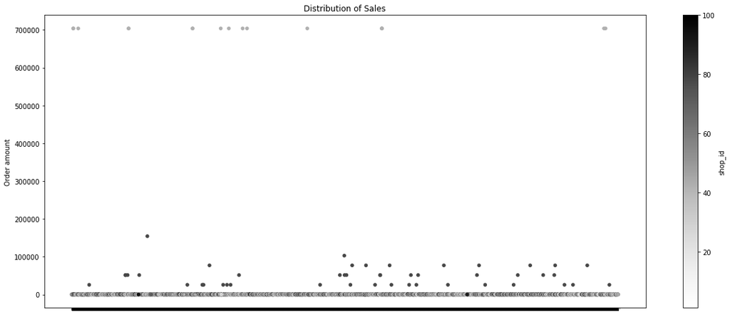

```python
dataset.plot(kind='scatter',x='created_at',y='order_amount',c='shop_id')
plt.xlabel('Date')
plt.ylabel('Order amount')
plt.title('Distribution of Sales')
plt.gcf().set_size_inches((20,8))
```

From the plot above we can tell our outliers are values much greater than 200000 price mark

```python
outliers = dataset[['shop_id','order_amount','total_items']] [dataset['order_amount'] > 200000].reset_index()
outliers
```

|  | index | shop_id | order_amount | total_items |
| --- | --- | --- | --- | --- |
| 0 | 15 | 42 | 704000 | 2000 |
| 1 | 60 | 42 | 704000 | 2000 |
| 2 | 520 | 42 | 704000 | 2000 |
| 3 | 1104 | 42 | 704000 | 2000 |
| 4 | 1362 | 42 | 704000 | 2000 |
| 5 | 1436 | 42 | 704000 | 2000 |
| 6 | 1562 | 42 | 704000 | 2000 |
| 7 | 1602 | 42 | 704000 | 2000 |
| 8 | 2153 | 42 | 704000 | 2000 |
| 9 | 2297 | 42 | 704000 | 2000 |
| 10 | 2835 | 42 | 704000 | 2000 |
| 11 | 2969 | 42 | 704000 | 2000 |
| 12 | 3332 | 42 | 704000 | 2000 |
| 13 | 4056 | 42 | 704000 | 2000 |
| 14 | 4646 | 42 | 704000 | 2000 |
| 15 | 4868 | 42 | 704000 | 2000 |
| 16 | 4882 | 42 | 704000 | 2000 |

From the observation above we can see that our data has 17 outliers. All of which are of the same order amount and are sold from the same shop 42.

But it would intrest you to know that even though they are significantly high values, it doesn't mean there was an imputation error. Shop 42 seems to have regularly sold bulk orders containing 2000 shoes, which is the reason for order values up to 704,000 dollars and ultimately the noise in the data.

### **2. What metric would you report for this dataset?**

Using AOV is actually not bad because it aims to measure central price of orders, we may have just used it in a wrong way.

Recall that the AOV for all our 5000 observations was somewhere around $3145.

Since items per order are somewhat categorical in nature with users buying either 1,2,3,4,5,6,8 or 2000 items, it will be best to calculate AOV for each category.

The reason why this method is preffered is because the data is naturally noisy and calculating AOV across all orders will result in an innacurate representation of order values. So, what we do is we bin similar order quantities together and calculate their AOV's.

### **3. What is its value?**

To employ the method stated above...

```python
binquantity = dataset.groupby('total_items')['order_amount'].mean().reset_index()
binquantity.rename(columns={'total_items':'Quantity', 'order_amount':'AOV'},inplace=True)
```

|  | Quantity | AOV |
| --- | --- | --- |
| 0 | 1 | 417.364481 |
| 1 | 2 | 750.215066 |
| 2 | 3 | 1191.076514 |
| 3 | 4 | 947.686007 |
| 4 | 5 | 759.350649 |
| 5 | 6 | 17940.000000 |
| 6 | 8 | 1064.000000 |
| 7 | 2000 | 704000.000000 |

This would be considered a better approach to calculating the AOV, given a particular category of quantities across all orders.

## **Question 2**

Given a dataset about customers, employees and order details

### **1. How many orders were shipped by Speedy Express in total?**

```python
SELECT ShipperName, COUNT(*)
FROM Orders
INNER JOIN Shippers
USING(ShipperID)
GROUP BY Orders.ShipperID;
```

54 orders were shipped by Speedy Express.

### **2. What is the last name of the employee with the most orders?**

```python
SELECT LastName, COUNT(Orders.EmployeeID)
FROM Orders
INNER JOIN Employees
USING(EmployeeID)
GROUP BY Orders.EmployeeID
ORDER BY COUNT(Orders.EmployeeID) DESC;
```

Employee with the last name "Peacock" has made the highest orders with a value of 40

### **3. What product was ordered most by customers in Germany?**

```python
SELECT ProductName, COUNT(Products.ProductName) AS OrdersCount
FROM Products
INNER JOIN OrderDetails USING(ProductID)
INNER JOIN Orders USING(OrderID)
INNER JOIN Customers USING(CustomerID)
WHERE Country = 'Germany'
GROUP BY Products.ProductID
ORDER BY  OrdersCount DESC;
```

Gorgonzola Telino was the highest ordered product by Germans with 5 orders.